# Read data

Mark Klik & Misja Mikkers

# Introduction

We will work with data in this course. Often your data will be stored in excel files (with extension .xls or .xlsx) or csv (comma separated values) files (with extension .csv). CSV-files can be opened in excel.

In this course we will teach you how to open excel and csv files. However, in general you can open virtually all data files (e.g. SPSS and Stata). Please use google if you need to do this.

## Packages

```r
library(tidyverse)
library(readxl)
```

# Basic directory structure

It will be handy to create a directory structure for your project with one folder with the name Code (in which you will save your notebook), one folder with the name Sourcedata (where we will save all the source data) and a folder named Output (where we will save any output that we want to save).

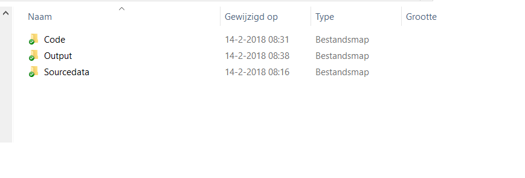

Directory Structure

In the following examples we assume that you have structured your directory structure as indicated above.

# Read csv-files

## Read and specify the path

We will start to read the csv-file “football.csv”. This is a file with the ranking of the Dutch football teams in 2015/2016.

We will use the command `your_dataframe <- read.csv2("file_name.csv")`. “Your_dataframe” is the name that you give to the dataframe. In this example we will call the dataframe “football”

However, this only works if the data file is located in the same folder as the notebook. In this case we have saved our data in the folder “Sourcedata” and the code in the folder “Code”. Therefore, we need to tell R where to find the datafile.

We can include the path in the “file_name”. In this example we tell R to go 1 folder up by “..” and then go to the right folder “Sourcedata” like this:

```r
football <- read.csv2("../Sourcedata/football.csv")
```

## Inspect the dataframe

We now have read the data. There are a few ways to inspect the data.

If we want to say the whole dataframe we can just type the name of the dataframe:

```r
football
```

| Club | Points | Budget |
| --- | --- | --- |
| ADO | 43 | 13 |
| Ajax | 82 | 65 |
| AZ | 59 | 28 |
| Cambuur | 18 | 7 |
| De Graafschap | 23 | 7 |
| Excelsior | 30 | 5 |
| Feyenoord | 63 | 50 |
| Groningen | 50 | 22 |
| Heereveen | 42 | 22 |
| Heracles | 51 | 10 |

[output cut: 8 more lines]

This may not be very practical if you have very large dataframes. With the command `head(name_dataframe)`, you can see the first rows of the dataframe,

```r
head(football)
```

|  | Club | Points | Budget |
| --- | --- | --- | --- |
| 1 | ADO | 43 | 13 |
| 2 | Ajax | 82 | 65 |
| 3 | AZ | 59 | 28 |
| 4 | Cambuur | 18 | 7 |
| 5 | De Graafschap | 23 | 7 |
| 6 | Excelsior | 30 | 5 |

while with `tail(name_dataframe)` you can see the last rows:

```r
tail(football)
```

|  | Club | Points | Budget |
| --- | --- | --- | --- |
| 13 | PSV | 84 | 63 |
| 14 | Roda | 34 | 10 |
| 15 | Twente | 40 | 36 |
| 16 | Utrecht | 53 | 17 |
| 17 | Vitesse | 46 | 28 |
| 18 | Willem II | 29 | 9 |

With the command `summary(name_dataframe)`, you will get a summary of your dataset:

```r
summary(football)
```

```
            Club        Points          Budget
 ADO          : 1   Min.   :18.00   Min.   : 5.00
 Ajax         : 1   1st Qu.:35.50   1st Qu.: 9.25
 AZ           : 1   Median :46.00   Median :15.00
 Cambuur      : 1   Mean   :46.72   Mean   :22.89
 De Graafschap: 1   3rd Qu.:52.50   3rd Qu.:28.00
 Excelsior    : 1   Max.   :84.00   Max.   :65.00
 (Other)      :12
```

## Common issue

We will now read another dataset about the Dutch football league

([source](http://www.football-data.co.uk/netherlandsm.php)). We have downloaded the csv already, under the name “N1.csv”

```r
football1 <- read.csv2("../Sourcedata/N1.csv")
```

If we have a look at the data, we see the following

```r
head(football1)
```

|  | Div.Date.HomeTeam.AwayTeam.FTHG.FTAG.FTR.HTHG.HTAG.HTR.B365H.B365D.B365A.BWH.BWD.BWA.IWH.IWD.IWA.LBH.LBD.LBA.PSH.PSD.PSA.WHH.WHD.WHA.VCH.VCD.VCA.Bb1X2.BbMxH.BbAvH.BbMxD.BbAvD.BbMxA.BbAvA.BbOU.BbMx.2.5… |
| --- | --- |
| 1 | N1,11/08/17,Den Haag,Utrecht,0,3,A,0,1,A,3.6,3.4,2.05,3.9,3.6,1.95,3.3,3.3,2,3.6,3.2,2.1,3.84,3.62,2.05,3.5,3.4,2,3.8,3.5,2,40,3.9,3.62,3.62,3.43,2.14,2.02,36,2.03,1.96,1.94,1.84,17,0.5,1.88,1.84,2.07… |
| 2 | N1,12/08/17,Heracles,Ajax,2,1,H,0,0,D,7,4.33,1.44,7.25,4.75,1.42,7,4.5,1.4,7,4.33,1.4,7.57,5.14,1.43,6.5,4.33,1.44,7.5,4.75,1.4,41,8.22,7.16,5.14,4.59,1.46,1.41,34,1.68,1.64,2.32,2.18,17,1.25,2,1.94,1… |
| 3 | N1,12/08/17,PSV Eindhoven,AZ Alkmaar,3,2,H,1,1,D,1.4,4.75,7,1.44,4.6,7.25,1.3,5,8.5,1.44,4.6,7.5,1.45,5.27,6.85,1.35,4.8,7.5,1.4,5,7,41,1.45,1.41,5.5,4.82,8.5,6.7,33,1.5,1.45,2.8,2.64,17,-1.25,1.98,1.… |
| 4 | N1,12/08/17,Vitesse,NAC Breda,4,1,H,3,0,H,1.53,4.2,5.75,1.55,4.25,5.75,1.5,4.2,5.5,1.53,4,5.5,1.56,4.53,6.03,1.53,4,5.5,1.53,4.3,6,41,1.57,1.54,4.53,4.19,6.03,5.54,34,1.69,1.61,2.35,2.23,18,-1,1.98,1.… |
| 5 | N1,12/08/17,VVV Venlo,Sparta Rotterdam,3,0,H,1,0,H,2.25,3.3,3.2,2.1,3.5,3.5,2.2,3.4,2.95,2.1,3.25,3.3,2.17,3.49,3.6,2.15,3.3,3.2,2.1,3.5,3.5,41,2.25,2.14,3.5,3.35,3.6,3.33,40,1.99,1.9,1.97,1.87,18,-0.… |
| 6 | N1,13/08/17,Feyenoord,Twente,2,1,H,1,1,D,1.25,5.5,12,1.26,5.75,12,1.25,5.5,10,1.22,5.75,13,1.25,6.7,13.2,1.22,6,11,1.22,6.25,13,39,1.26,1.23,6.7,6.02,14.3,11.3,31,1.55,1.51,2.63,2.47,17,-1.75,1.92,1.8… |

All the data are in 1 column!

“CSV” is an abbrevation of Comma Separated Value. When this format was developed, observations were separated by ‘comma’s’. In some countries, e.g. the Netherlands, values are separated by “;”. `read.csv2` assumes that the values are separated by “;” If you read a file where values are separated with “,”, the command `read.csv2` does not recognize this. There are several ways to solve this issue. The most practical way is to specify the way the file separated the values. In the case of the file “N1”, a comma is used to separate the values:

```r
football2 <- read.csv2("../Sourcedata/N1.csv", sep=",")
head(football2)
```

|  | Div | Date | HomeTeam | AwayTeam | FTHG | FTAG | FTR | HTHG | HTAG | HTR | B365H | B365D | B365A | BWH | BWD | BWA | IWH | IWD | IWA | LBH | LBD | LBA | PSH | PSD | PSA | WHH | WHD | WHA | VCH | … |
| --- | --- | --- | --- | --- | --- | --- | --- | --- | --- | --- | --- | --- | --- | --- | --- | --- | --- | --- | --- | --- | --- | --- | --- | --- | --- | --- | --- | --- | --- | --- |
| 1 | N1 | 11/08/17 | Den Haag | Utrecht | 0 | 3 | A | 0 | 1 | A | 3.6 | 3.4 | 2.05 | 3.9 | 3.6 | 1.95 | 3.3 | 3.3 | 2 | 3.6 | 3.2 | 2.1 | 3.84 | 3.62 | 2.05 | 3.5 | 3.4 | 2 | 3.8 | … |
| 2 | N1 | 12/08/17 | Heracles | Ajax | 2 | 1 | H | 0 | 0 | D | 7 | 4.33 | 1.44 | 7.25 | 4.75 | 1.42 | 7 | 4.5 | 1.4 | 7 | 4.33 | 1.4 | 7.57 | 5.14 | 1.43 | 6.5 | 4.33 | 1.44 | 7.5 | … |
| 3 | N1 | 12/08/17 | PSV Eindhoven | AZ Alkmaar | 3 | 2 | H | 1 | 1 | D | 1.4 | 4.75 | 7 | 1.44 | 4.6 | 7.25 | 1.3 | 5 | 8.5 | 1.44 | 4.6 | 7.5 | 1.45 | 5.27 | 6.85 | 1.35 | 4.8 | 7.5 | 1.4 | … |
| 4 | N1 | 12/08/17 | Vitesse | NAC Breda | 4 | 1 | H | 3 | 0 | H | 1.53 | 4.2 | 5.75 | 1.55 | 4.25 | 5.75 | 1.5 | 4.2 | 5.5 | 1.53 | 4 | 5.5 | 1.56 | 4.53 | 6.03 | 1.53 | 4 | 5.5 | 1.53 | … |
| 5 | N1 | 12/08/17 | VVV Venlo | Sparta Rotterdam | 3 | 0 | H | 1 | 0 | H | 2.25 | 3.3 | 3.2 | 2.1 | 3.5 | 3.5 | 2.2 | 3.4 | 2.95 | 2.1 | 3.25 | 3.3 | 2.17 | 3.49 | 3.6 | 2.15 | 3.3 | 3.2 | 2.1 | … |
| 6 | N1 | 13/08/17 | Feyenoord | Twente | 2 | 1 | H | 1 | 1 | D | 1.25 | 5.5 | 12 | 1.26 | 5.75 | 12 | 1.25 | 5.5 | 10 | 1.22 | 5.75 | 13 | 1.25 | 6.7 | 13.2 | 1.22 | 6 | 11 | 1.22 | … |

# Read excel files

## Read excel files

Often you will get your data in the form of an excel sheet. There are several packages available to read excel files in R. For this course, we will use the package “readxl”

We will use the same data as above, only in a different format. We have loaded the package “readxl” at the top of this notebook. We can now read the excel sheet

```r
football_points <-read_xlsx("../Sourcedata/football.xlsx")
head(football_points)
```

| Eredivisie 2015/2016 | X__1 |
| --- | --- |
| NA | NA |
| NA | NA |
| Club | Points |
| PSV | 84 |
| Ajax | 82 |
| Feyenoord | 63 |

Looking at the data, we see that the excel sheet is read in to a dataframe including empty rows and a name that is not necessary. We can repair this using the package “dplyr” (which we will use later in the course), but we can also use the command `skip`. In this case we do not want to read the first 3 rows in to our dataframe.

```r
football_points1 <-read_xlsx("../Sourcedata/football.xlsx", skip=3)
head(football_points1)
```

| Club | Points |
| --- | --- |
| PSV | 84 |
| Ajax | 82 |
| Feyenoord | 63 |
| AZ | 59 |
| Utrecht | 53 |
| Heracles | 51 |

## Read separate sheets

If you have opened the excel sheet, you might have noticed that the excel sheet has two worksheets. We only have read the first sheet. Now we will read the second worksheet as well:

```r
football_budget <-read_xlsx("../Sourcedata/football.xlsx", sheet="Budgets", skip=3)
head(football_budget)
```

| Club | Budget |
| --- | --- |
| PSV | 63 |
| Ajax | 65 |
| Feyenoord | 50 |
| AZ | 28 |
| Utrecht | 17 |
| Heracles | 10 |

In stead of `sheet="Budgets"`, we could have used `sheet=2`

```r
football_budget1 <-read_xlsx("../Sourcedata/football.xlsx", sheet=2, skip=3)
head(football_budget1)
```

| Club | Budget |
| --- | --- |
| PSV | 63 |
| Ajax | 65 |
| Feyenoord | 50 |
| AZ | 28 |
| Utrecht | 17 |
| Heracles | 10 |

Later today, we will show how to merge the two data frames.

# Writing data

It is possible to write a dataframe as a csv-file, with the command `write.csv2`. This is not often needed, because all the data editing is reproducible with the script. But sometimes you may want to write your dataframe as a csv-file. We will save the csv-file in the folder “Output”

```r
write.csv2(football, file = "../Output/Myfootballdata.csv")
```

# The structure of the dataset

There are few common types of data:

- Character (“letters”)g
- Numeric (Real numbers)
- Integer
- Complex (Complexe numbers, e.g. 2+3i)
- Logical (True / False)
- Factors (Categorical data: e.g. “male”, “female”)

And with the command `str(name_dataframe)` you will get the structure of your dataframe

```r
str(football)
```

```
'data.frame':   18 obs. of  3 variables:
 $ Club  : Factor w/ 18 levels "ADO","Ajax","AZ",..: 1 2 3 4 5 6 7 8 9 10 ...
 $ Points: int  43 82 59 18 23 30 63 50 42 51 ...
 $ Budget: int  13 65 28 7 7 5 50 22 22 10 ...
```

In this example we see that the variable “Club” is a factor and the variables “Points” and “Budgets” are integers.

## Change the structure of your dataframe

We can change the nature of the variables in several ways. Here we will show you a simple way (later we learn how to do this using the package “dplyr” (which is part of the larger package “tidyverse”)).

Suppose you want to change the variable “Club” in to a string of characters and

```r
football$Club <- as.character(football$Club)
```

change the variable “Points” into a new varible “Points_numeric” which is a numeric vector:

```r
football$Points_numeric <- as.numeric(football$Points)
```

We can now check we our commands worked:

```r
str(football)
```

```
'data.frame':   18 obs. of  4 variables:
 $ Club          : chr  "ADO" "Ajax" "AZ" "Cambuur" ...
 $ Points        : int  43 82 59 18 23 30 63 50 42 51 ...
 $ Budget        : int  13 65 28 7 7 5 50 22 22 10 ...
 $ Points_numeric: num  43 82 59 18 23 30 63 50 42 51 ...
```

You can now change the structure of all variables. There is one **Warning**:

### Change factors into numerics

You cannot change a vector of “factors” directly into a vector of “numerics”, because “factors” are levels. As an illustration we create a vector called “variable_factor” with levels 3 and 4.

```r
variable_factor <- as.factor(c(3,3,3,3,3,4,4,4))
```

We can check the structure by the command `str()`

```r
str(variable_factor)
```

```
 Factor w/ 2 levels "3","4": 1 1 1 1 1 2 2 2
```

We will now directly change this factor in to a numerical vector (“variable_nume”) and see what happens:

```r
variable_numeric_wrong <- as.numeric(variable_factor)
variable_numeric_wrong
```

```
[1] 1 1 1 1 1 2 2 2
```

R returns a vector of 1’s and 2’s, because a vector of factor is not a vector of “numbers”, but a vector with “levels”. To do this correctly we may change the factor first into a “character” and then into a numeric:

```r
variable_numeric <- as.numeric(as.character(variable_factor))
variable_numeric
```

```
[1] 3 3 3 3 3 4 4 4
```